# Export/Import assets with `ibm-watsonx-ai`

This notebook demonstrates an example for exporting/importing assets using watsonx.ai Runtime service. It contains steps and code to work with ibm-watsonx-ai library available in PyPI repository.

Some familiarity with Python is helpful. This notebook uses Python 3.12.

## Learning goals

The learning goals of this notebook are:

- Download an externally trained Keras model.
- Persist an external model in watsonx.ai Runtime repository.
- Export the model from the space
- Import the model to another space and deploy

## Contents

This notebook contains the following parts:

1. Set up the environment
2. Download externally created Keras model and data
3. Persist externally created Keras model
4. Export the model
5. Import the model
6. Deploy and score the imported model
7. Cleanup
8. Summary and next steps

## 1. Set up the environment

Before you use the sample code in this notebook, you must perform the following setup tasks:

- Create a [watsonx.ai Runtime Service](https://cloud.ibm.com/catalog/services/watsonxai-runtime) instance (a free plan is offered and information about how to create the instance can be found [here](https://dataplatform.cloud.ibm.com/docs/content/wsj/getting-started/wml-plans.html?context=wx&audience=wdp)).

### Install and import the `ibm-watsonx-ai` and dependecies

**Note:** `ibm-watsonx-ai` documentation can be found [here](https://ibm.github.io/watsonx-ai-python-sdk/index.html).

```python
%pip install wget | tail -n 1
%pip install matplotlib | tail -n 1
%pip install -U ibm-watsonx-ai | tail -n 1
```

### Connection to watsonx.ai Runtime

Authenticate the watsonx.ai Runtime service on IBM Cloud. You need to provide platform `api_key` and instance `location`.

You can use [IBM Cloud CLI](https://cloud.ibm.com/docs/cli/index.html) to retrieve platform API Key and instance location.

API Key can be generated in the following way:

```
ibmcloud login
ibmcloud iam api-key-create API_KEY_NAME
```

In result, get the value of `api_key` from the output.

Location of your watsonx.ai Runtime instance can be retrieved in the following way:

```
ibmcloud login --apikey API_KEY -a https://cloud.ibm.com
ibmcloud resource service-instance INSTANCE_NAME
```

In result, get the value of `location` from the output.

**Tip**: Your `Cloud API key` can be generated by going to the [**Users** section of the Cloud console](https://cloud.ibm.com/iam#/users). From that page, click your name, scroll down to the **API Keys** section, and click **Create an IBM Cloud API key**. Give your key a name and click **Create**, then copy the created key and paste it below. You can also get a service specific url by going to the [**Endpoint URLs** section of the watsonx.ai Runtime docs](https://cloud.ibm.com/apidocs/machine-learning). You can check your instance location in your [watsonx.ai Runtime Service](https://cloud.ibm.com/catalog/services/watsonxai-runtime) instance details.

You can also get service specific apikey by going to the [**Service IDs** section of the Cloud Console](https://cloud.ibm.com/iam/serviceids). From that page, click **Create**, then copy the created key and paste it below.

**Action**: Enter your `url` and `api_key` in the following cell.

```python
import getpass

from ibm_watsonx_ai import Credentials

credentials = Credentials(
    url="https://us-south.ml.cloud.ibm.com",
    api_key=getpass.getpass("Please enter your watsonx.ai api key (hit enter): "),
)
```

```python
from ibm_watsonx_ai import APIClient

client = APIClient(credentials)
```

### Create two spaces. One for export and one for import

**Tip**: You can refer to details and example for space management apis [here](https://github.com/IBM/watson-machine-learning-samples/blob/master/cloud/notebooks/python_sdk/instance-management/Space%20management.ipynb).

```python
# Refer to the link in above tip how to find the COS and instance CRNs
cos_resource_crn = "PASTE_YOUR_COS_CRN"
instance_crn = "PASTE_YOUR_WML_INSTANCE_CRN"
name = "PASTE_YOUR_INSTANCE_NAME_HERE"
```

```python
import uuid

space_name = str(uuid.uuid4())
```

```python
export_space_metadata = {
    client.spaces.ConfigurationMetaNames.NAME: "client_space_export_" + space_name,
    client.spaces.ConfigurationMetaNames.DESCRIPTION: space_name + " description",
    client.spaces.ConfigurationMetaNames.STORAGE: {"resource_crn": cos_resource_crn},
    client.spaces.ConfigurationMetaNames.COMPUTE: {"name": name, "crn": instance_crn},
}

space = client.spaces.store(meta_props=export_space_metadata, background_mode=False)

export_space_id = client.spaces.get_id(space)
```

```
##################################################################################

Synchronous space creation with id: 'd5ffc00c-837b-402a-839f-450f35ca184f' started

##################################################################################


preparing
active

------------------------------------------------------------------------------

Creating space  'd5ffc00c-837b-402a-839f-450f35ca184f' finished successfully.
------------------------------------------------------------------------------
```

```python
import_space_metadata = {
    client.spaces.ConfigurationMetaNames.NAME: "client_space_import_" + space_name,
    client.spaces.ConfigurationMetaNames.DESCRIPTION: space_name + " description",
    client.spaces.ConfigurationMetaNames.STORAGE: {"resource_crn": cos_resource_crn},
    client.spaces.ConfigurationMetaNames.COMPUTE: {"name": name, "crn": instance_crn},
}

space = client.spaces.store(meta_props=import_space_metadata, background_mode=False)

import_space_id = client.spaces.get_id(space)
```

```
##################################################################################

Synchronous space creation with id: '3d8d02c2-de18-4ad2-8c9c-b4e69be485f6' started

##################################################################################


preparing
active

------------------------------------------------------------------------------

Creating space  '3d8d02c2-de18-4ad2-8c9c-b4e69be485f6' finished successfully.
------------------------------------------------------------------------------
```

## 2. Download externally created Keras model and data

In this section, you will download externally created Keras models and data used for training it.

```python
import os

import wget

model_path = "mnist-keras-model.h5.zip"
if not os.path.isfile(model_path):
    wget.download(
        "https://github.com/IBM/watsonx-ai-samples/raw/master/cloud/models/keras/mnist-keras-model.h5.zip"
    )
```

```python
import os

import wget

data_dir = "MNIST_DATA"
if not os.path.isdir(data_dir):
    os.mkdir(data_dir)

filename = os.path.join(data_dir, "mnist.npz")
if not os.path.isfile(filename):
    wget.download("https://s3.amazonaws.com/img-datasets/mnist.npz", out=data_dir)
```

```python
import numpy as np

dataset = np.load(filename)
x_test = dataset["x_test"]
```

## 3. Persist externally created Keras model

In this section, you will learn how to store your model in watsonx.ai Runtime repository by using the watsonx.ai Client.

### 3.1: Publish model

Define model name, type and software specification needed to deploy model later.

```python
software_spec_id = client.software_specifications.get_id_by_name("runtime-25.1-py3.12")
```

```python
client.set.default_space(export_space_id)

metadata = {
    client.repository.ModelMetaNames.NAME: "External Keras model",
    client.repository.ModelMetaNames.TYPE: "tensorflow_2.18",
    client.repository.ModelMetaNames.SOFTWARE_SPEC_ID: software_spec_id,
}

published_model = client.repository.store_model(model=model_path, meta_props=metadata)
```

### 3.2: Get model details

```python
import json

published_model_id = client.repository.get_model_id(published_model)
model_details = client.repository.get_details(published_model_id)
print(json.dumps(model_details, indent=2))
```

```
{
  "metadata": {
    "name": "External Keras model",
    "space_id": "d5ffc00c-837b-402a-839f-450f35ca184f",
    "resource_key": "4f3dccd1-9d46-49ab-879d-efd8ffa5d8c6",
    "id": "88d5f6a9-6fce-4046-b1af-94cc05e5201c",
    "created_at": "2026-01-19T09:35:51Z",
    "rov": {
      "member_roles": {
        "IBMid-696000GJGB": {
          "user_iam_id": "IBMid-696000GJGB",
          "roles": [
            "OWNER"
          ]
        }
      }
    },
    "owner": "IBMid-696000GJGB"
  },
  "entity": {
    "software_spec": {
      "id": "f47ae1c3-198e-5718-b59d-2ea471561e9e"
    },
    "type": "tensorflow_2.18"
  }
}
```

### 3.3 Get all models in the space

space_id is automatically picked up from client.set.default_space() api call before

```python
models_details = client.repository.list_models()
```

## 4. Export the model

```python
help(client.export_assets.start)
```

```
Help on method start in module ibm_watsonx_ai.export_assets:

start(meta_props: 'dict[str, str | bool | list]', space_id: 'str | None' = None, project_id: 'str | None' = None) -> 'dict[str, Any]' method of ibm_watsonx_ai.export_assets.Export instance
    Start the export. You must provide the space_id or the project_id.
    ALL_ASSETS is by default False. You don't need to provide it unless it is set to True.
    You must provide one of the following in the meta_props: ALL_ASSETS, ASSET_TYPES, or ASSET_IDS. Only one of these can be
    provided.

    In the `meta_props`:

    ALL_ASSETS is a boolean. When set to True, it exports all assets in the given space.
    ASSET_IDS is an array that contains the list of assets IDs to be exported.
    ASSET_TYPES is used to provide the asset types to be exported. All assets of that asset type will be exported.

        Eg: wml_model, wml_model_definition, wml_pipeline, wml_function, wml_experiment,
        software_specification, hardware_specification, package_extension, script

    :param meta_props: metadata,
        to see available meta names use ``client.export_assets.ConfigurationMetaNames.get()``
    :type meta_props: dict

    :param space_id: space identifier
    :type space_id: str, optional

    :param project_id: project identifier
    :type project_id: str, optional

    :return: Response json
    :rtype: dict

    **Example:**

    .. code-block:: python

        metadata = {
            client.export_assets.ConfigurationMetaNames.NAME: "export_model",
            client.export_assets.ConfigurationMetaNames.ASSET_IDS: [
                "13a53931-a8c0-4c2f-8319-c793155e7517",
                "13a53931-a8c0-4c2f-8319-c793155e7518",
            ],
```

[output cut: 14 more lines]

```

        details = client.export_assets.start(
            meta_props=metadata, space_id="98a53931-a8c0-4c2f-8319-c793155e4598"
        )

    .. code-block:: python

        metadata = {
            client.export_assets.ConfigurationMetaNames.NAME: "export_model",
            client.export_assets.ConfigurationMetaNames.ALL_ASSETS: True,
        }

        details = client.export_assets.start(
            meta_props=metadata, space_id="98a53931-a8c0-4c2f-8319-c793155e4598"
        )
```

client.export_assets has these apis. For any help on these apis, type 'help(api_name)' in your notebook Example: help(client.export_assets.start), help(client.export_assets.get_details)

1. client.export_assets.start: This starts the export job. export job is asynchronously executed
2. client.export_assets.get_details: Given export_id and corresponding space_id/project_id, this gives the export job details. Usually used for monitoring the export job submitted with start api
3. client.export_assets.list: Prints summary of all the export jobs
4. client.export_assets.get_exported_content: Downloads the exported content. This information will be used by the import process
5. client.export_assets.delete: Deletes the given export job
6. client.export_assets.cancel: Cancels the given export job if running

### 4.1: Start the export process

Start the export process for the model created. Either ASSET_IDS or ASSET_TYPES or ALL_ASSETS can be provided. If you have more than one model ids, you need to provide them as array like client.export_assets.ConfigurationMetaNames.ASSET_IDS: [model_id1, model_id2] Refer to the help api above to see different usages and details

```python
metadata = {
    client.export_assets.ConfigurationMetaNames.NAME: "export_model",
    client.export_assets.ConfigurationMetaNames.ASSET_IDS: [published_model_id],
}

details = client.export_assets.start(meta_props=metadata, space_id=export_space_id)
print(json.dumps(details, indent=2))

export_job_id = details["metadata"]["id"]
```

```
export job with id 9ae088d7-194b-4d4e-9323-fc3570996821 has started. Monitor status using client.export_assets.get_details api. Check 'help(client.export_assets.get_details)' for details on the api usage
{
  "entity": {
    "assets": {
      "all_assets": false,
      "asset_ids": [
        "88d5f6a9-6fce-4046-b1af-94cc05e5201c"
      ]
    },
    "format": "json",
    "status": {
      "state": "pending"
    }
  },
  "metadata": {
    "created_at": "2026-01-19T09:36:01.446Z",
    "creator_id": "IBMid-696000GJGB",
    "id": "9ae088d7-194b-4d4e-9323-fc3570996821",
    "name": "export_model",
    "space_id": "d5ffc00c-837b-402a-839f-450f35ca184f",
    "url": "/v2/asset_exports/9ae088d7-194b-4d4e-9323-fc3570996821"
  }
}
```

### 4.2: Monitor the export process

```python
import time

start_time = time.time()
diff_time = start_time - start_time
while True and diff_time < 10 * 60:
    time.sleep(3)
    response = client.export_assets.get_details(export_job_id, space_id=export_space_id)
    state = response["entity"]["status"]["state"]
    print(state)
    if state == "completed" or state == "error" or state == "failed":
        break
    diff_time = time.time() - start_time

print(json.dumps(response, indent=2))
```

```
completed
{
  "entity": {
    "assets": {
      "all_assets": false,
      "asset_ids": [
        "88d5f6a9-6fce-4046-b1af-94cc05e5201c"
      ]
    },
    "format": "json",
    "status": {
      "state": "completed"
    }
  },
  "metadata": {
    "created_at": "2026-01-19T09:36:01.446Z",
    "creator_id": "IBMid-696000GJGB",
    "id": "9ae088d7-194b-4d4e-9323-fc3570996821",
    "name": "export_model",
    "space_id": "d5ffc00c-837b-402a-839f-450f35ca184f",
    "updated_at": "2026-01-19T09:36:04.610Z",
    "url": "/v2/asset_exports/9ae088d7-194b-4d4e-9323-fc3570996821"
  }
}
```

### 4.3: Get the exported content

```python
export_dir = "EXPORT_DATA"

if not os.path.isdir(export_dir):
    os.mkdir(export_dir)

export_file_name = "exported_content_" + str(uuid.uuid4()) + ".zip"

export_file_path = os.path.join(export_dir, export_file_name)

details = client.export_assets.get_exported_content(
    export_job_id, space_id=export_space_id, file_path=export_file_path
)

print(details)
```

```
Successfully saved export content to file: 'EXPORT_DATA/exported_content_4a37d2b9-4500-4abf-bbed-c628c8806fed.zip'
EXPORT_DATA/exported_content_4a37d2b9-4500-4abf-bbed-c628c8806fed.zip
```

## 5. Import the model

client.import_assets has these apis. For any help on these apis, type 'help(api_name)' in your notebook Example: help(client.import_assets.start), help(client.import_assets.get_details)

1. client.import_assets.start: This starts the import job. import job is asynchronously executed
2. client.import_assets.get_details: Given import_id and corresponding space_id/project_id, this gives the import job details. Usually used for monitoring the import job submitted with start api
3. client.import_assets.list: Prints summary of all the import jobs
4. client.import_assets.delete: Deletes the given import job
5. client.import_assets.cancel: Cancels the given import job if running

### 5.1: Start the import process

```python
details = client.import_assets.start(
    file_path=export_file_path, space_id=import_space_id
)
print(json.dumps(details, indent=2))

import_job_id = details["metadata"]["id"]
```

```
import job with id 0d2532f8-d4b9-4008-adae-2c1e51f0a53c has started. Monitor status using client.import_assets.get_details api. Check 'help(client.import_assets.get_details)' for details on the api usage
{
  "entity": {
    "format": "json",
    "status": {
      "state": "pending"
    }
  },
  "metadata": {
    "created_at": "2026-01-19T09:36:15.937Z",
    "creator_id": "IBMid-696000GJGB",
    "id": "0d2532f8-d4b9-4008-adae-2c1e51f0a53c",
    "space_id": "3d8d02c2-de18-4ad2-8c9c-b4e69be485f6",
    "url": "/v2/asset_imports/0d2532f8-d4b9-4008-adae-2c1e51f0a53c"
  }
}
```

### 5.2: Monitor the import process

```python
import time

start_time = time.time()
diff_time = start_time - start_time
while True and diff_time < 10 * 60:
    time.sleep(3)
    response = client.import_assets.get_details(import_job_id, space_id=import_space_id)
    state = response["entity"]["status"]["state"]
    print(state)
    if state == "completed" or state == "error" or state == "failed":
        break
    diff_time = time.time() - start_time

print(json.dumps(response, indent=2))

client.set.default_space(import_space_id)

print("{}List of models: {}".format("\n", "\n"))
client.repository.list_models()
details = client.repository.get_model_details()

for obj in details["resources"]:
    if obj["metadata"]["name"] == "External Keras model":
        model_id_for_deployment = obj["metadata"]["id"]

print("{}model id for deployment: {}".format("\n", model_id_for_deployment))
```

```
running
completed
{
  "entity": {
    "format": "json",
    "status": {
      "state": "completed"
    }
  },
  "metadata": {
    "created_at": "2026-01-19T09:36:15.937Z",
    "creator_id": "IBMid-696000GJGB",
    "id": "0d2532f8-d4b9-4008-adae-2c1e51f0a53c",
    "space_id": "3d8d02c2-de18-4ad2-8c9c-b4e69be485f6",
    "updated_at": "2026-01-19T09:36:21.860Z",
    "url": "/v2/asset_imports/0d2532f8-d4b9-4008-adae-2c1e51f0a53c"
  }
}

List of models:


model id for deployment: 502536fc-8cf1-4d76-9da6-34e4c1fbacfc
```

List the import and export jobs

```python
print("Export jobs: \n")
client.export_assets.list(space_id=export_space_id)
```

```
Export jobs:
```

|  | ID | NAME | CREATED | STATUS |
| --- | --- | --- | --- | --- |
| 0 | 9ae088d7-194b-4d4e-9323-fc3570996821 | export_model | 2026-01-19T09:36:01.446Z | completed |

```python
print("\nImport jobs:")
client.import_assets.list(space_id=import_space_id)
```

```
Import jobs:
```

|  | ID | CREATED | STATUS |
| --- | --- | --- | --- |
| 0 | 0d2532f8-d4b9-4008-adae-2c1e51f0a53c | 2026-01-19T09:36:15.937Z | completed |

## 6. Deploy and score the imported model

### 6.1: Create model deployment

#### Create online deployment for published model

```python
metadata = {
    client.deployments.ConfigurationMetaNames.NAME: "Deployment of external Keras model",
    client.deployments.ConfigurationMetaNames.ONLINE: {},
}

created_deployment = client.deployments.create(
    model_id_for_deployment, meta_props=metadata
)
```

```
######################################################################################

Synchronous deployment creation for id: '502536fc-8cf1-4d76-9da6-34e4c1fbacfc' started

######################################################################################


initializing
Note: online_url and serving_urls are deprecated and will be removed in a future release. Use inference instead.
......
ready


-----------------------------------------------------------------------------------------------
Successfully finished deployment creation, deployment_id='9819e543-8b53-42b1-8409-a58255a69b63'
-----------------------------------------------------------------------------------------------
```

```python
deployment_id = client.deployments.get_id(created_deployment)
```

Now you can print an online scoring endpoint.

```python
scoring_endpoint = client.deployments.get_scoring_href(created_deployment)
print(scoring_endpoint)
```

[output not shown]

You can also list existing deployments.

```python
client.deployments.list()
```

|  | ID | NAME | STATE | CREATED | ARTIFACT_TYPE | SPEC_STATE | SPEC_REPLACEMENT |
| --- | --- | --- | --- | --- | --- | --- | --- |
| 0 | 9819e543-8b53-42b1-8409-a58255a69b63 | Deployment of external Keras model | ready | 2026-01-19T09:36:37.770Z | model | supported |  |

### 6.2: Get deployment details

```python
details = client.deployments.get_details(deployment_id)
print(json.dumps(details, indent=2))
```

[output not shown]

### 6.3: Score

You can use below method to do test scoring request against deployed model.

Let's first visualize two samples from dataset, we'll use for scoring. You must have matplotlib package installed

```python
%matplotlib inline
import matplotlib.pyplot as plt
```

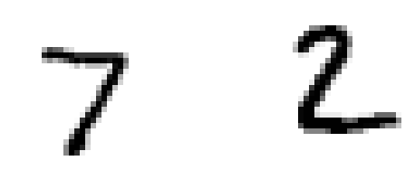

```python
for i, image in enumerate([x_test[0], x_test[1]]):
    plt.subplot(2, 2, i + 1)
    plt.axis("off")
    plt.imshow(image, cmap=plt.cm.gray_r, interpolation="nearest")
```

Prepare scoring payload with records to score.

```python
score_0 = x_test[0].reshape(28, 28, 1)
score_1 = x_test[1].reshape(28, 28, 1)
```

```python
scoring_payload = {"input_data": [{"values": [score_0, score_1]}]}
```

Use `client.deployments.score()` method to run scoring.

```python
predictions = client.deployments.score(deployment_id, scoring_payload)
```

```python
print(json.dumps(predictions, indent=2))
```

```
{
  "predictions": [
    {
      "fields": [
        "prediction"
      ],
      "id": "y_hat",
      "values": [
        [
          2.1161436052352656e-06,
          9.53357170985214e-10,
          4.728389346730921e-10,
          3.943275572737548e-08,
          0.00011951127089560032,
          1.438263979025578e-07,
          2.1252301252161487e-08,
          0.9995545744895935,
          8.875564958543691e-07,
          0.0003227672423236072
        ],
        [
          0.021077046170830727,
          0.1209486722946167,
          0.8552001714706421,
          0.0012876029359176755,
          4.0436454582959414e-05,
          0.0004892426659353077,
          0.00048998644342646,
          9.553693234920502e-05,
          0.00018569448729977012,
          0.00018568598898127675
        ]
      ]
    }
  ]
}
```

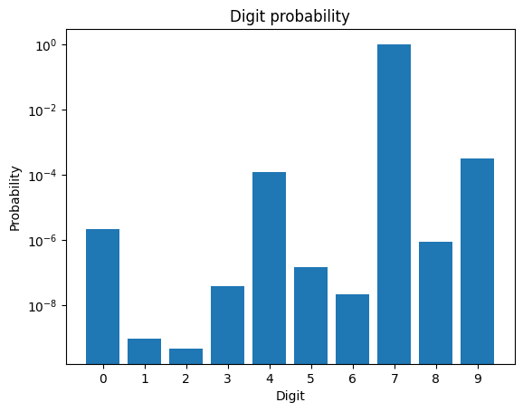

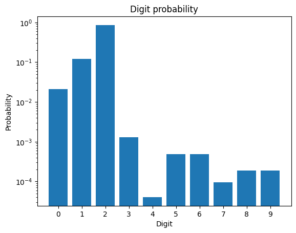

```python
for i, prediction in enumerate(predictions["predictions"][0]["values"]):
    plt.bar(range(10), prediction)
    plt.title("Digit probability")
    plt.xlabel("Digit")
    plt.ylabel("Probability")
    plt.xticks(range(10))
    plt.yscale("log")
    plt.show()
```

## 7. Cleanup

```python
client.export_assets.delete(export_job_id, space_id=export_space_id)
client.import_assets.delete(import_job_id, space_id=import_space_id)

client.spaces.delete(export_space_id)
client.spaces.delete(import_space_id)
```

```
Export job deleted
Import job deleted
```

```
'SUCCESS'
```

If you want to clean up all created assets:

- experiments
- trainings
- pipelines
- model definitions
- models
- functions
- deployments

please follow up this sample [notebook](https://github.com/IBM/watson-machine-learning-samples/blob/master/cloud/notebooks/python_sdk/instance-management/Machine%20Learning%20artifacts%20management.ipynb).

## 8. Summary and next steps

You successfully completed this notebook! You learned how to use export/import assets client apis. Check out our *[Online Documentation](https://dataplatform.cloud.ibm.com/docs/content/wsj/getting-started/welcome-main.html?context=wx)* for more samples, tutorials, documentation, how-tos, and blog posts.

### Authors and Maintainers

**Mateusz Szewczyk (Former)**, Software Engineer at IBM watsonx.ai

**Rafał Chrzanowski**, Software Engineer at IBM watsonx.ai

**Karol Zmorski**, Software Engineer at IBM watsonx.ai

Copyright © 2020-2026 IBM. This notebook and its source code are released under the terms of the MIT License.